# Binomial Distribution

# Probability Functions

A **probability function** assigns probabilities to outcomes in a sample space.

In other words, a probability function **maps the r.v. into the the real numbers between 0 and 1**.

**Types:**

- *Probability Mass Function (PMF):* PMFs are for discrete random variables
- *Probability Density Functions (PDF):* PDFs are for continuous random variables

$\star$ **Key Idea:** We can define a probability function directly from the sample space, but using a random variable makes it explicit what outcomes we want to compute probabilities for in a given scenario.

# Flipping One Coin R.V.

Suppose we conduct an experiment of flipping a fair coin once.

- Let $S = \{H,T\}$ be the sample space.
- Let $X$ be the r.v. that counts the number of $H$ outcomes.
- The r.v. is given by
  $$\begin{aligned}
  X(H) & = 1 \\
  X(T) & = 0 \\
  \end{aligned}$$

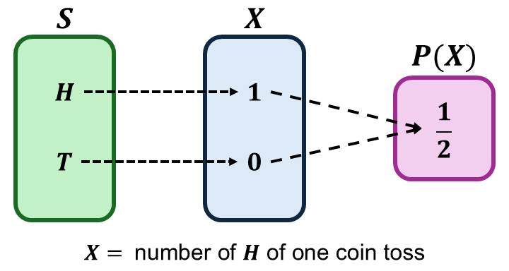

$\star$ **Key Idea:** A random variable for a coin toss maps the sample space $\{H,T\}$ to real values, assigning $X(H)=1$ and $X(T)=0$. The probability function $P(X)$ then defines the probability space.

# R.V. of Binary Outcomes

Suppose we conduct an experiment of one randomized outcome from a binary r.v..

A **binary r.v.** $X$ is a variable that takes only two possible values, typically labelled as “success” and “failure”.

- Let $S = \{\text{success},\text{failure}\}$ be the sample space.
- The r.v. is given by
  $$\begin{aligned}
  X(\text{success}) & = 1 \\
  X(\text{failure}) & = 0 \\
  \end{aligned}$$

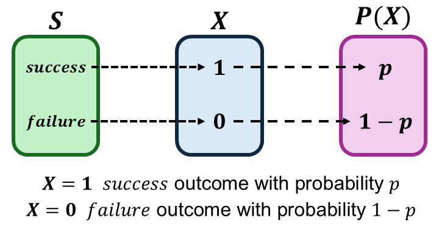

$\star$ **Key Idea:** A r.v. with binary outcome is called the **Bernoulli R.V.** with a probability of “success” $p$ and “failure” $1-p$, where $p$ is called the *parameter*. One trial with binary outcomes is called a **Bernoulli trial**.

# The Bernoulli R.V. and PMF

A **Bernoulli r.v.** represents a single experiment with two possible outcomes: “success” ($X=1$) with probability $p$ and failure ($X=0$) with probability $1-p$. We typically define an r.v. using $\sim$ along with the name and its parameter:
$$X \sim
\text{Bern}(p)$$

The **Bernoulli distribution** is a **probability mass function** that computes the probability of the Bernoulli r.v..

$$P(X = x) =
\begin{cases}
p & \text{, if } x = 1 \\
1-p & \text{, if } x = 0
\end{cases}.$$

where $p$ is the parameter (also the probability of “success”).

# Case Study 1

A hospital is testing a new antibiotic for treating bacterial pneumonia. Researchers conduct a clinical trial where patients receive either the new antibiotic or a standard treatment, and their recovery outcomes are recorded.

**Binary Outcome:**

- Each patient’s response to treatment is categorized as:
  - Recovered –Patient shows no signs of infection after treatment
  - Not Recovered –Infection persists or worsens

**Data Collection & Analysis:**

- *Patients divided into two groups:* New antibiotic vs. Standard treatment
- *Binary Outcomes:* Recovery sample proportions compared
- *Key Research Question:* Does the new antibiotic significantly improve recoveries compared to the standard treatment?

$\star$ **Key Idea:** This example is simplified and it serves the building block of all statistical studies, which includes observational and experimental studies.

# Flipping Two Coins R.V.

Suppose we conduct an experiment of flipping two fair coins in a sequence.

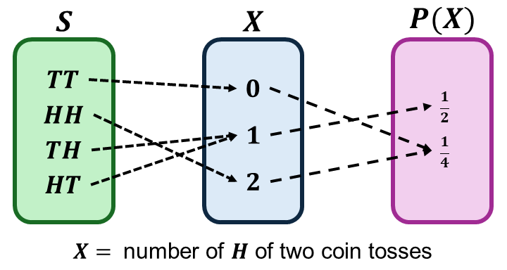

$\star$ **Key Idea:** The PMF $P(X)$ satisfies the probability axioms, and the collection of all probabilities forms the probability distribution.

# Flipping $\mathbf{n}$ Coins: Possible Outcomes

Suppose we conduct an experiment of flipping $n$ fair coins in a sequence, where $n$ is an integer. The sample space $S$ contains all possible sequences of $H$ and $T$. Number of possible outcomes is $|S| = 2^n$.

**Visualizing the possible outcomes using Pascal’s triangle**

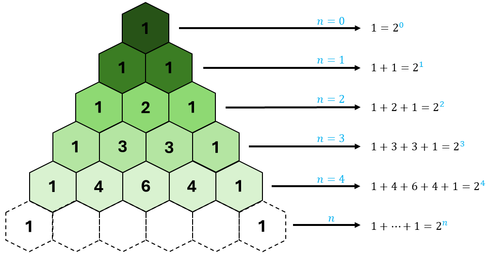

$\star$ **Key Idea:** Pascal’s Triangle helps us visualize the total possible sequences of “success” ($H$) outcomes given $n$ independent trials.

# Flipping $\mathbf{n}$ Coins: Counting the Number of $H$ outcomes

Let $X$ be the r.v. that counts the number of $H$ outcomes in $n$ trials.

**Pascal’s triangle helps us count**

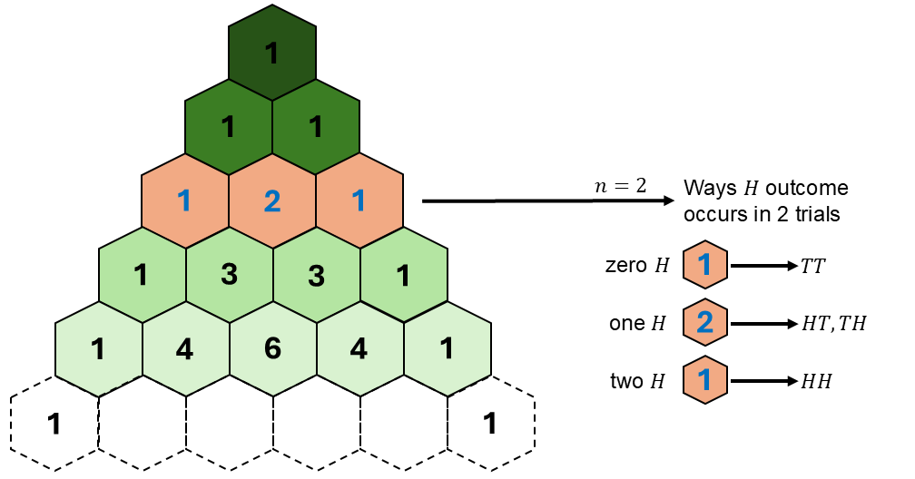

$\dagger$ Can you determine the ways $H$ can occur in $4$ trials using Pascal’s triangle?

# Flipping $\mathbf{n}$ Coins: Probability of Observing $H$ outcomes in $n$ Trials

Compute the probability of observing a certain number of “success” ($H$) outcomes in $n$ trials.

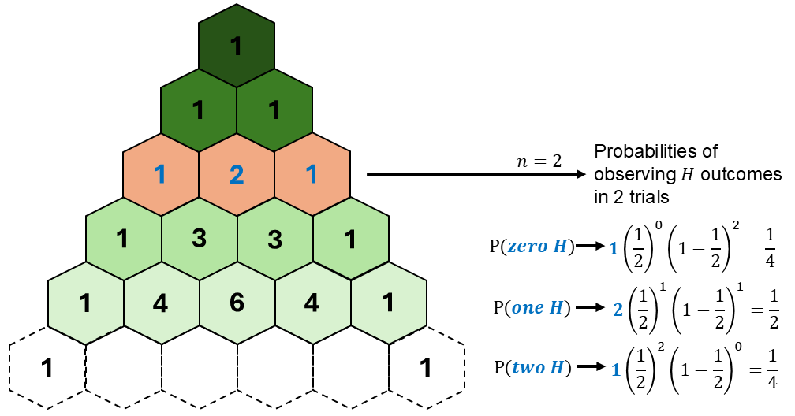

$\dagger$ Can you determine the probabilities of observing $H$ outcomes in $4$ trials?

# Flipping $\mathbf{n}$ Coins: The Expected Number of $H$ outcomes in $n$ Trials

How many $H$ outcomes do we expect to have in $n$ independent Bernoulli trials with “success” probability $p$?

**Example**

- Each fair coin flip is an independent Bernoulli trial with:
  - $P(H) = \frac{1}{2}$
  - $P(T) = 1 - \frac{1}{2}$
- Suppose that $n=2$.
  - We expect to have $2 \times \frac{1}{2} = 1$ $H$ outcome in $2$ trials.

**In general:**

- The expected value of “success” outcomes is $\text{E}(X) = n \times p$.
- The binomial coefficient tells you how many ways $k$ “success” outcomes can occur in $n$ trials, corresponding to the $k$-th column in the $n$-th row of Pascal’s Triangle.

$\star$ **Key Idea:** Over many repetitions, the long-run average number of “success” outcomes is $n \times p$, reflecting the frequentist interpretation of probability.

# The Binomial R.V. and PMF

A **binomial R.V.** is a discrete random variable representing the number of “success” in $n$ independent Bernoulli trials, each with “success” probability $p$:
$$X \sim \text{Binom}(n,p)$$

The **Binomial distribution** is a **probability mass function** that computes the probability of the Binomial r.v..

$$P(X=k) = \binom{n}{k} p^k (1-p)^{n-k}, \
k = 0,1,2,3, \cdots, n$$
where $p$ is the “success” probability. The term $\binom{n}{k}$ is the binomial coefficient or the numbers in the Pascal’s triangle.

The **expected value** or the **theoretical mean** of “success” outcomes is $n \times p$.

$\star$ **Key Idea:** Computing Binomial probabilities can be tedious but you can use R to compute these probabilities efficiently and accurately. *We will have more discussions about using R for the Binomial PMF later.*

# Case Study 2

A hospital is preparing for the flu season by estimating the number of patients who will require hospitalization due to severe influenza. Over a one-month period, $100$ flu-positive patients are tracked to determine whether they need hospital admission. Based on the data, the hospitalization rate is approximately $1$ in every $3$ patients.

**Binomial Outcomes**

- Each patient’s hospitalization outcome is independent and classified as:
  - Hospitalized –Patient requires admission for severe symptoms
  - Not Hospitalized –Patient recovers without hospitalization
- There were $100$ patients studied. This was an observational study.

**Rate Interpretation**

- The estimated hospitalization rate is $1$ in every $3$ patients.
- The rate $1$ in every $3$ means that there is a $\frac{1}{3}$ probability that a flu-positive patient will be hospitalized.

$\star$ **Key Idea:** This is an example of a Binomial r.v. because we are given a fixed number of independent patients and there is only two possible outcomes in each patient.

# Case Study 2: Expectation

Suppose a hospital receives 10 flu-positive patients at a given time. Based on a known estimated hospitalization rate of $\frac{1}{3}$, each patient is expected to have an independent probability of $\frac{1}{3}$ of requiring hospitalization.

- $n = 10$ is the total flu-positive patients coming in the hospital
- $p = \frac{1}{3}$ is the proportion estimate that a flu-positive patient requires hospitalization
- The expected number of flu-positive patients that requires hospitalization:
  - $n \times p = 10 \times \frac{1}{3} \approx 3.333$
  - The hospital expects to admit $3.333$ ($\approx 3$ or $\approx 4$) patients on average

$\star$ **Key Idea:** While the rate was originally estimated from a study involving 100 patients, we are applying it to a smaller sample of only 10 patients, meaning that the actual number of hospitalizations may vary due to random fluctuations.

# Case Study 2: Binomial Probability

Consider the same scenario where a small hospital receives 10 flu-positive patients at a given time with estimated hospitalization rate of $\frac{1}{3}$.

What is the probability that a hospital get $3$ patients to be hospitalized?

**Computation**

- Use the Binomial PMF
- $\begin{aligned}P(X=3) & = \binom{10}{3} \left( \frac{1}{3} \right)^3 \left(1-\frac{1}{3} \right)^{10-3} \\ & = 120 \left( \frac{1}{3} \right)^3 \left(\frac{2}{3} \right)^{7} \\ & \approx 0.2601 \end{aligned}$

**Interpretation**

- There is $26.01$% probability that the hospital admits exactly $3$ patients given $10$ flu-positive patients coming in the long-run.

$\dagger$ How would you write the binomial probability that a hospital get $4$ patients to be hospitalized? What about $3$ or $4$ patients? What rules of probability are applied?

# Visualizing the Binomial Distribution

**Binomial Distribution**

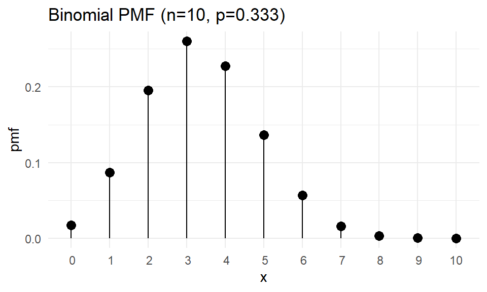

**Binomial R.V.**

Let $p=\frac{1}{3}$ be the “success” probability and $n=10$ the number of trials.

$$\begin{aligned}
\text{R.V. } & \longrightarrow X \sim \text{Binom}(p) \\
\text{PMF } & \longrightarrow P(X=k) = \binom{n}{k} p^k (1-p)^{n-k}
\\
\text{for } & k = 0,1,2,3, \cdots, n
\end{aligned}$$

# Binomial Probabilities (1/2)

**Binomial Distribution**

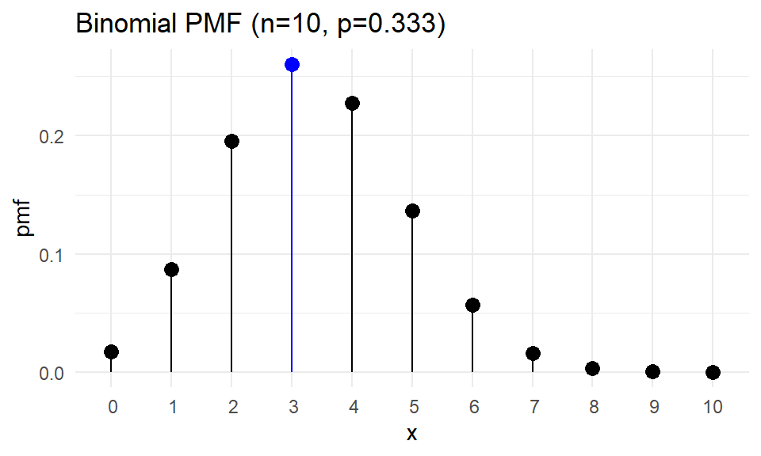

**Example:**

What is the probability of getting 3 “success” in 10 trials with $p=\frac{1}{3}$?
$$\begin{aligned}
P(X=3) & = \binom{10}{3} \left( \frac{1}{3} \right)^3 \left(
1-\frac{1}{3} \right)^{10-3} \\
& = 120 \left( \frac{1}{3} \right)^3 \left( \frac{2}{3}
\right)^7 \\
P(X=3) & \approx 0.2601
\end{aligned}$$

**Using R:**

```r
n <- 10
p <- 1/3
k <- 3
dbinom(k,n,p)
```

```
## [1] 0.2601229
```

$\star$ Note that the `dbinom()` function computes the probability $P(X = k)$, meaning it computes the probability at exactly $X=k$ using the Binomial PMF.

# Binomial Probabilities (2/2)

**Binomial Distribution**

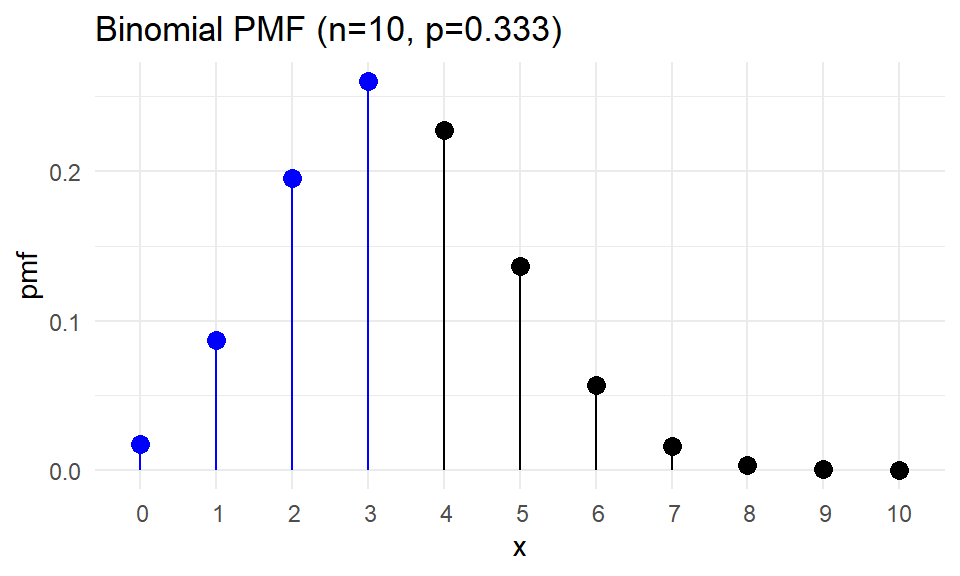

**Example:**

What is the probability of getting at most 3 “success” in 10 trials with $p=\frac{1}{3}$?
$$\begin{aligned}
P(X \le 3) & = P(X = 0) + P(X = 1) + P(X=2) + P(X = 3) \\
& = \sum_{k=0}^3 \binom{10}{k} \left( \frac{1}{3}
\right)^k \left( 1-\frac{1}{3} \right)^{10-k} \\
P(X \le 3) & \approx 0.5593 \\
\end{aligned}$$

**Using R:**

```r
n <- 10
p <- 1/3
k <- 3
pbinom(3,n,p)
```

```
## [1] 0.5592643
```

$\star$ Note that the `pbinom()` function computes the probability $P(X \le k)$, meaning it computes the sum of all probabilities from $X=0$ to $X=k$ using the Binomial PMF.

# Activity: Observing the Binomial Distribution

1. Make sure you have a copy of the *F 2/21 Worksheet*. This will be handed out physically and it is also digitally available on Moodle.
2. Work on your worksheet by yourself for 10 minutes. Please read the instructions carefully. Ask questions if anything need clarifications.
3. Get together with another student.
4. Discuss your results.
5. Submit your worksheet on Moodle as a `.pdf` file.

# References

Diez, D. M., Barr, C. D., & Çetinkaya-Rundel, M. (2012). *OpenIntro statistics* (4th ed.). OpenIntro. https://www.openintro.org/book/os/

# Appendix: The Binomial Coefficient

**Pascal’s Triangle and Combinations** This formula calculates the number of ways to choose $k$ elements from a set of $n$. Each number in Pascal’s Triangle corresponds to a combination. Also known as the **binomial coefficient**.

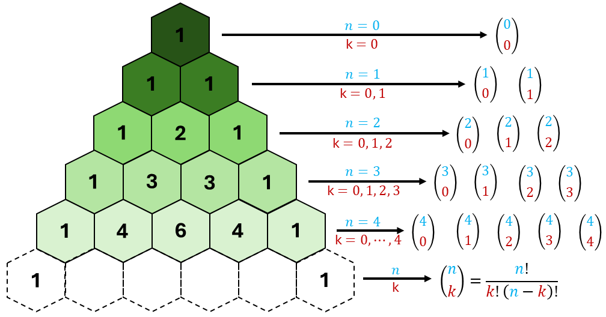